# COMPSCIX 415.2 Homework 3 SOLUTION

Robert Clements

DUE DATE: Feb 20, 2018 @ 6:15PM

# Exercises

## Section 3.8.1: all exercises

### 1.

The problem with the plot is that there are many overlapping points due to the discrete nature of the two variables.

```r
library(tidyverse)
library(nycflights13)
```

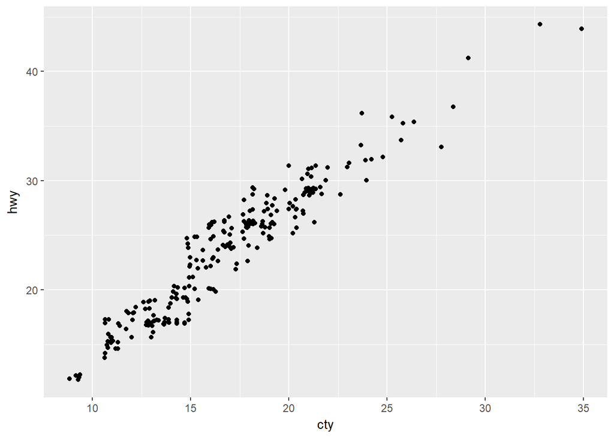

```r
ggplot(data = mpg, mapping = aes(x = cty, y = hwy)) +
  geom_point(position = 'jitter')
```

### 2.

The `width` and `height` parameters control the amount of jittering, the smaller the values, the less jittering there is.

### 3.

From the plots below we see that `geom_count()` changes the size of the points in relation to the number of individual points at each location. Both plots try to reveal the *density* of points. However, it’s a bit harder to interpret the `geom_count()` plot because of the extra aesthetic of point area that has to be interpreted. There’s the added complication of possible overlap between circles in `geom_count()`. `geom_count()` doesn’t move the points at all, which may be important when there are some exact coordinates that are useful to know (it’s almost never important to know exact coordinates for ALL of the points).

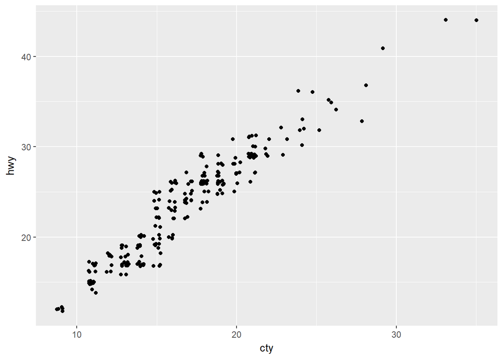

```r
ggplot(data = mpg, mapping = aes(x = cty, y = hwy)) +
  geom_jitter(width = .25, height = .25)
```

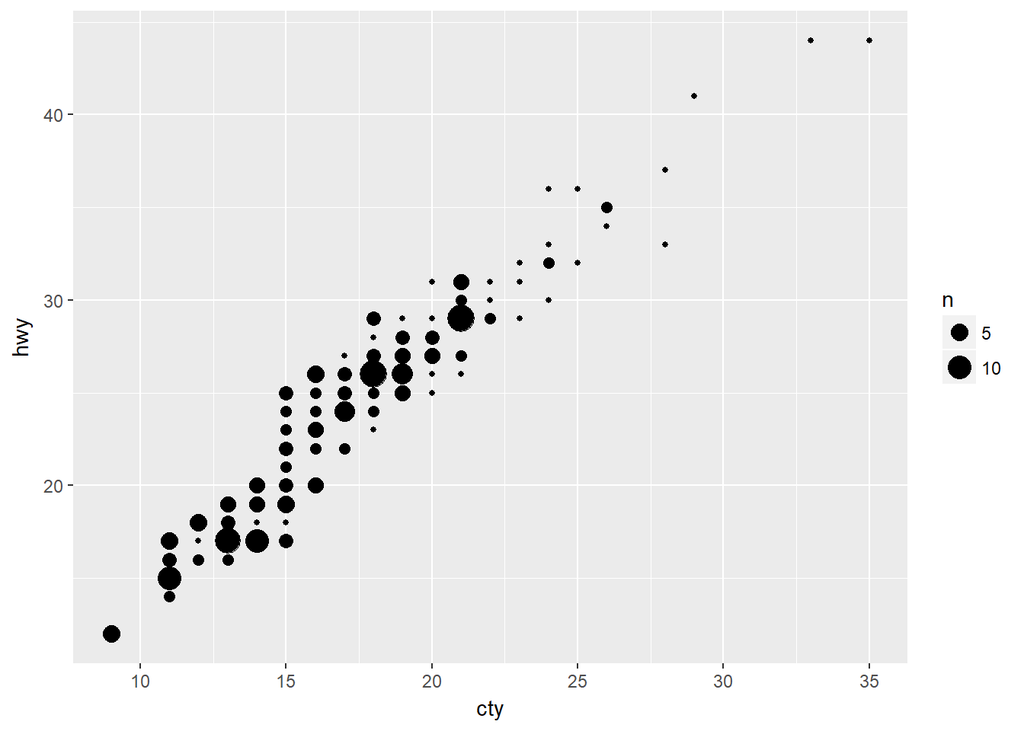

```r
ggplot(data = mpg, mapping = aes(x = cty, y = hwy)) +
  geom_count()
```

### 4.

From the help file we can see that the default position is “dodge”. This plot shows what happens when you use “dodge” versus “identity”.

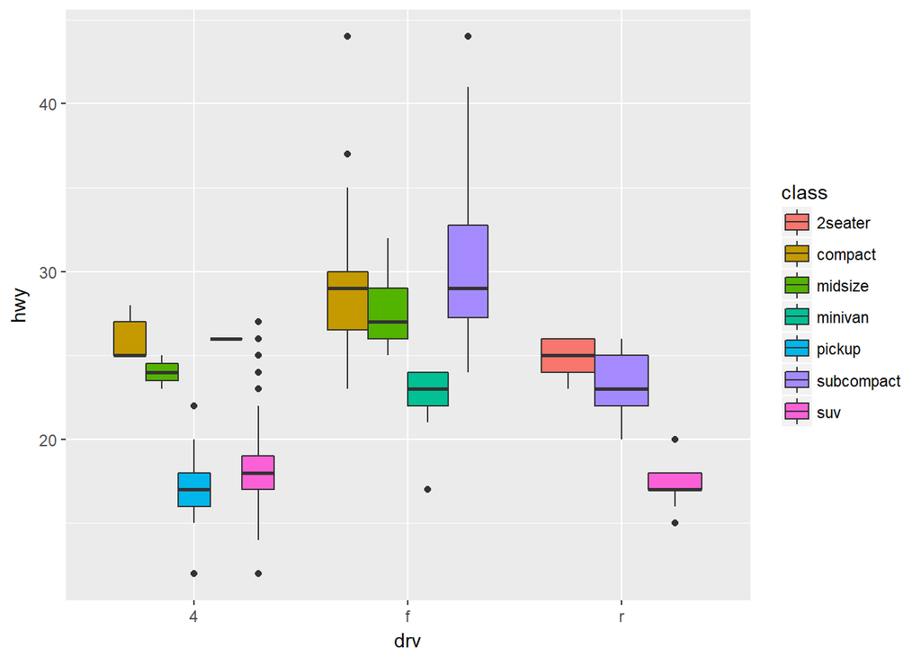

```r
ggplot(data = mpg, mapping = aes(x = drv, y = hwy, fill = class)) +
  geom_boxplot()
```

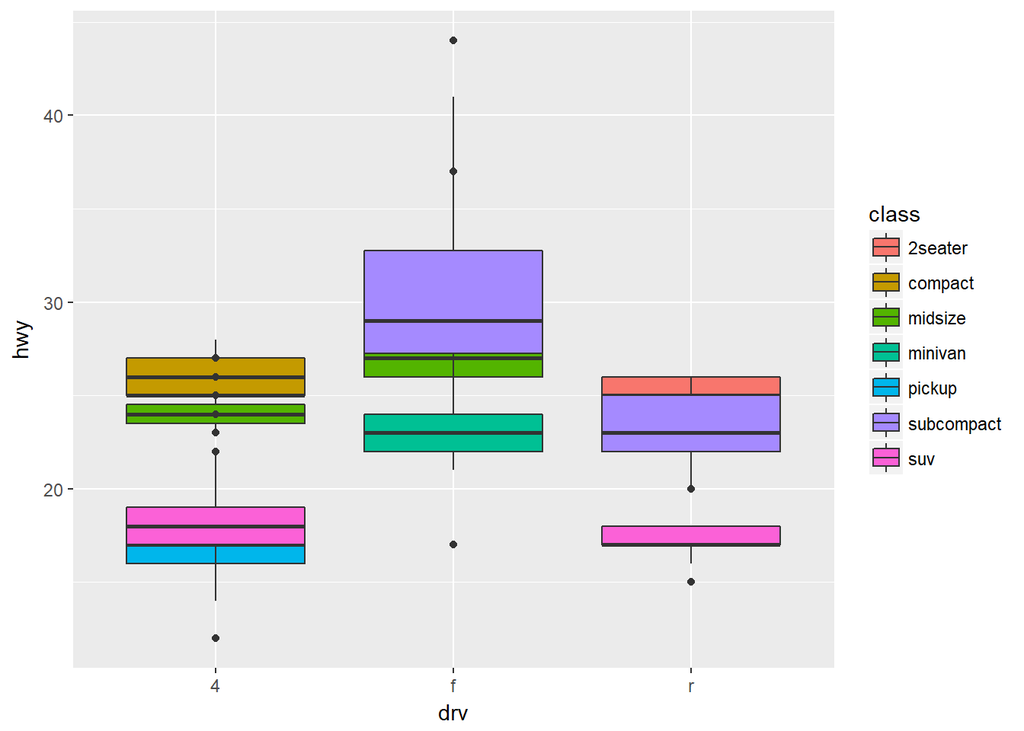

```r
ggplot(data = mpg, mapping = aes(x = drv, y = hwy, fill = class)) +
  geom_boxplot(position = 'identity')
```

## Section 3.9.1: #2 and #4 only

### 2.

`labs()` is a function for setting labels for aesthetics (e.g. x-axis, y-axis, color), title, subtitle, and caption.

### 4.

The plot shows an obvious strong positive correlation in city and highway fuel mileage, where highway fuel mileage is always a bit higher than the city fuel mileage. By using `coord_fixed()` the scale of the x- and y-axis are kept the same. Without it, we can see that the x-axis gets stretched out even though we know that `cty` and `hwy` are of the same units (mpg).

`geom_abline()` plots a line given a slope and intercept. The default slope = 1 and intercept = 0. This line helps us see that the highway fuel mileage is always higher than the city mileage.

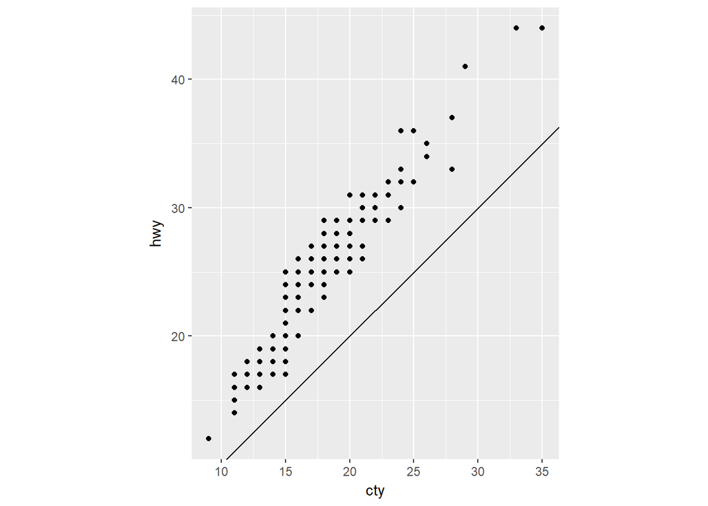

```r
ggplot(data = mpg, mapping = aes(x = cty, y = hwy)) +
  geom_point() +
  geom_abline() +
  coord_fixed()
```

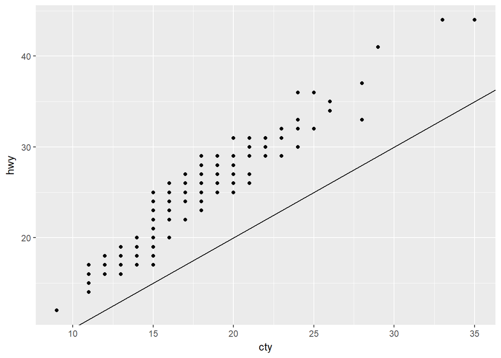

```r
ggplot(data = mpg, mapping = aes(x = cty, y = hwy)) +
  geom_point() +
  geom_abline()
```

## Section 4.4: #1 and #2 only

### 1.

The code doesn’t work because `my_varıable` is not the same as `my_variable`, because there is no `i` in the first piece of code. However, this seems to be wrong because it worked fine for me.

### 2.

```r
library(tidyverse)

ggplot(data = mpg) +
  geom_point(mapping = aes(x = displ, y = hwy))

filter(mpg, cyl == 8)
filter(diamonds, carat > 3)
```

## Section 5.2.4: all exercises

### 1.

```r
# 1.
ans_one <- flights %>% filter(arr_delay >= 120)

# 2.
ans_two <- flights %>% filter(dest %in% c('IAH', 'HOU'))

# 3.
ans_three <- flights %>% filter(carrier %in% c('UA', 'AA', 'DL'))

# 4.
ans_four <- flights %>% filter(month %in% c(7, 8, 9))

# 5.
ans_five <- flights %>% filter(arr_delay > 120 & dep_delay <= 0)

# 6.
ans_six <- flights %>% filter(dep_delay >= 60 & arr_delay <= (dep_delay-30))

# 7.
ans_sev <- flights %>% filter(dep_time >= 0 & dep_time <= 600)
```

### 2.

The `between()` function is a shortcut for using `x >= left & x <= right`.

```r
ans_sev_2 <- flights %>% filter(between(dep_time, 0, 600))
```

### 3.

There are 8255 flights with missing departure times. Departure and arrival times and delays and air time seem to be all missing. These rows might represent some kind of mechanical failure, data entry failure, or some otherwise canceled flight.

```r
miss_rows <- flights %>% filter(is.na(dep_time))
glimpse(miss_rows)
```

```
## Observations: 8,255
## Variables: 19
## $ year           <int> 2013, 2013, 2013, 2013, 2013, 2013, 2013, 2013,...
## $ month          <int> 1, 1, 1, 1, 1, 1, 1, 1, 1, 1, 1, 1, 1, 1, 1, 1,...
## $ day            <int> 1, 1, 1, 1, 2, 2, 2, 2, 2, 2, 2, 2, 3, 3, 3, 3,...
## $ dep_time       <int> NA, NA, NA, NA, NA, NA, NA, NA, NA, NA, NA, NA,...
## $ sched_dep_time <int> 1630, 1935, 1500, 600, 1540, 1620, 1355, 1420, ...
## $ dep_delay      <dbl> NA, NA, NA, NA, NA, NA, NA, NA, NA, NA, NA, NA,...
## $ arr_time       <int> NA, NA, NA, NA, NA, NA, NA, NA, NA, NA, NA, NA,...
## $ sched_arr_time <int> 1815, 2240, 1825, 901, 1747, 1746, 1459, 1644, ...
## $ arr_delay      <dbl> NA, NA, NA, NA, NA, NA, NA, NA, NA, NA, NA, NA,...
## $ carrier        <chr> "EV", "AA", "AA", "B6", "EV", "EV", "EV", "EV",...
## $ flight         <int> 4308, 791, 1925, 125, 4352, 4406, 4434, 4935, 3...
## $ tailnum        <chr> "N18120", "N3EHAA", "N3EVAA", "N618JB", "N10575...
## $ origin         <chr> "EWR", "LGA", "LGA", "JFK", "EWR", "EWR", "EWR"...
## $ dest           <chr> "RDU", "DFW", "MIA", "FLL", "CVG", "PIT", "MHT"...
## $ air_time       <dbl> NA, NA, NA, NA, NA, NA, NA, NA, NA, NA, NA, NA,...
## $ distance       <dbl> 416, 1389, 1096, 1069, 569, 319, 209, 746, 645,...
## $ hour           <dbl> 16, 19, 15, 6, 15, 16, 13, 14, 13, 15, 13, 16, ...
## $ minute         <dbl> 30, 35, 0, 0, 40, 20, 55, 20, 21, 45, 30, 1, 45...
## $ time_hour      <dttm> 2013-01-01 16:00:00, 2013-01-01 19:00:00, 2013...
```

### 4.

Anything raised to 0 is equal to 1. In an OR condition, if either expression is TRUE, then the condition is TRUE, so it doesn’t matter if one condition is not known. In the AND condition, if either expression is FALSE, then the condition evaluates to FALSE, so it doesn’t matter if one condition is not known.

```r
NA ^ 0
```

```
## [1] 1
```

```r
NA | TRUE
```

```
## [1] TRUE
```

```r
NA & FALSE
```

```
## [1] FALSE
```

## Section 5.4.1: all exercises

### 1.

```r
opt_one <- flights %>% select(arr_time, arr_delay, dep_time, dep_delay)

opt_two <- flights %>% select(contains('time'), -air_time, -sched_dep_time)

opt_three <- flights %>% select(starts_with('dep'), starts_with('arr'))
```

### 2.

If we include the same variable name multiple times in the same `select()` function it will only return one instance of the variable.

```r
multi_sel <- flights %>% select(arr_time, arr_time)
```

### 3.

`one_of()` lets you select variables by using a vector of characters, or quoted variable names. This is useful if you want to define a vector of variable names outside of the `select()` function for other purposes. This is especially useful when you want to pass a *variable* list of names to `select()`, perhaps as part of a function that you wrote yourself.

```r
vars <- c("year", "month", "day", "dep_delay", "arr_delay")

flts_subset <- flights %>% select(one_of(vars))
```

### 4.

In the code below, it is surprising that all variables that contain `time` are returned given that R is usually so picky about case. There is an `ignore.case` argument for the helper functions that can be set to FALSE if we want to change the default.

```r
flts_subset <- select(flights, contains("TIME"))
```